# 🎓 IIMK Professional Certificate in Data Science and AI for Managers

## 📊 Assignment 9.1: Supervised Learning and Classification Models

### 👨‍🎓 Student Information:

- **Name:** Lalit Nayyar
- **Email:** lalitnayyar@gmail.com
- **Course:** Professional Certificate in Data Science and Artificial Intelligence for Managers
- **Institution:** Indian Institute of Management Kozhikode (IIMK)

## 📋 Assignment Overview

🔍 This project implements supervised learning techniques to predict income levels using the Adult Income Dataset. The assignment focuses on understanding classification models, their performance metrics, and data preprocessing techniques.

### Dataset Description

The Adult Income Dataset, also known as the Census Income dataset, contains demographic and employment-related features to predict whether an individual's annual income exceeds $50,000. This real-world dataset presents various data preprocessing and modeling challenges that are common in practical machine learning applications.

## 1. Data Preprocessing 🔄

### 1.a. Loading the Dataset

We begin by loading the Adult Income dataset. This dataset contains various demographic and employment-related features such as age, education, occupation, and other socio-economic factors that might influence an individual's income level.

The dataset features include:

- Numerical attributes: age, fnlwgt, education-num, capital-gain, capital-loss, hours-per-week
- Categorical attributes: workclass, education, marital-status, occupation, relationship, race, sex, native-country

```
Dataset Shape: (32561, 15)

First few rows of the dataset:
```

|  | age | workclass | fnlwgt | education | education-num | marital-status | occupation | relationship | race | sex | capital-gain | capital-loss | hours-per-week | native-country | income |
| --- | --- | --- | --- | --- | --- | --- | --- | --- | --- | --- | --- | --- | --- | --- | --- |
| 0 | 39 | State-gov | 77516 | Bachelors | 13 | Never-married | Adm-clerical | Not-in-family | White | Male | 2174 | 0 | 40 | United-States | <=50K |
| 1 | 50 | Self-emp-not-inc | 83311 | Bachelors | 13 | Married-civ-spouse | Exec-managerial | Husband | White | Male | 0 | 0 | 13 | United-States | <=50K |
| 2 | 38 | Private | 215646 | HS-grad | 9 | Divorced | Handlers-cleaners | Not-in-family | White | Male | 0 | 0 | 40 | United-States | <=50K |
| 3 | 53 | Private | 234721 | 11th | 7 | Married-civ-spouse | Handlers-cleaners | Husband | Black | Male | 0 | 0 | 40 | United-States | <=50K |
| 4 | 28 | Private | 338409 | Bachelors | 13 | Married-civ-spouse | Prof-specialty | Wife | Black | Female | 0 | 0 | 40 | Cuba | <=50K |

### 1.b. Exploratory Data Analysis (EDA)

Let's perform a comprehensive analysis of our dataset to understand:

- Data types of each feature
- Missing values
- Basic statistics of numerical columns
- Distribution of categorical variables

```
Dataset Info:
<class 'pandas.core.frame.DataFrame'>
RangeIndex: 32561 entries, 0 to 32560
Data columns (total 15 columns):
 #   Column          Non-Null Count  Dtype
---  ------          --------------  -----
 0   age             32561 non-null  int64
 1   workclass       32561 non-null  object
 2   fnlwgt          32561 non-null  int64
 3   education       32561 non-null  object
 4   education-num   32561 non-null  int64
 5   marital-status  32561 non-null  object
 6   occupation      32561 non-null  object
 7   relationship    32561 non-null  object
 8   race            32561 non-null  object
 9   sex             32561 non-null  object
 10  capital-gain    32561 non-null  int64
 11  capital-loss    32561 non-null  int64
 12  hours-per-week  32561 non-null  int64
 13  native-country  32561 non-null  object
 14  income          32561 non-null  object
dtypes: int64(6), object(9)
memory usage: 3.7+ MB

Missing Values:
age               0
workclass         0
fnlwgt            0
education         0
education-num     0
marital-status    0
occupation        0
relationship      0
race              0
sex               0
capital-gain      0
capital-loss      0
hours-per-week    0
native-country    0
income            0
dtype: int64

Numerical Columns Statistics:
                age        fnlwgt  education-num  capital-gain  capital-loss  \
count  32561.000000  3.256100e+04   32561.000000  32561.000000  32561.000000
mean      38.581647  1.897784e+05      10.080679   1077.648844     87.303830
std       13.640433  1.055500e+05       2.572720   7385.292085    402.960219
min       17.000000  1.228500e+04       1.000000      0.000000      0.000000
25%       28.000000  1.178270e+05       9.000000      0.000000      0.000000
50%       37.000000  1.783560e+05      10.000000      0.000000      0.000000
75%       48.000000  2.370510e+05      12.000000      0.000000      0.000000
max       90.000000  1.484705e+06      16.000000  99999.000000   4356.000000

       hours-per-week
count    32561.000000
mean        40.437456
std         12.347429
min          1.000000
25%         40.000000
50%         40.000000
75%         45.000000
max         99.000000
```

```
Unique values in workclass:
workclass
Private             0.697030
Self-emp-not-inc    0.078038
Local-gov           0.064279
?                   0.056386
State-gov           0.039864
Name: proportion, dtype: float64

Unique values in education:
education
HS-grad         0.322502
Some-college    0.223918
Bachelors       0.164461
Masters         0.052916
Assoc-voc       0.042443
Name: proportion, dtype: float64

Unique values in marital-status:
marital-status
Married-civ-spouse    0.459937
Never-married         0.328092
Divorced              0.136452
Separated             0.031479
Widowed               0.030497
Name: proportion, dtype: float64

Unique values in occupation:
occupation
Prof-specialty     0.127146
Craft-repair       0.125887
Exec-managerial    0.124873
Adm-clerical       0.115783
Sales              0.112097
Name: proportion, dtype: float64

Unique values in relationship:
relationship
Husband          0.405178
Not-in-family    0.255060
```

[output cut: 19 more lines]

```

Unique values in native-country:
native-country
United-States    0.895857
Mexico           0.019748
?                0.017905
Philippines      0.006081
Germany          0.004207
Name: proportion, dtype: float64

Unique values in income:
income
<=50K    0.75919
>50K     0.24081
Name: proportion, dtype: float64
```

### 1.c. Handling Missing and Erroneous Data

In this dataset, missing values are denoted by '?' rather than standard NULL or NaN values. We need to:

1. Identify these non-standard missing values
2. Replace them with appropriate values
3. Document our approach and rationale

```
Missing values after replacement:
age                  0
workclass         1836
fnlwgt               0
education            0
education-num        0
marital-status       0
occupation        1843
relationship         0
race                 0
sex                  0
capital-gain         0
capital-loss         0
hours-per-week       0
native-country     583
income               0
dtype: int64

Verifying no missing values remain:
0
```

## 2. Data Encoding 🔢

### 2.a. Converting Categorical Variables

We'll use Label Encoding for ordinal categorical variables and One-Hot Encoding for nominal categorical variables to preserve their interpretability.

```
Dataset shape after encoding: (32561, 91)

First few columns:
```

|  | age | fnlwgt | education | education-num | capital-gain | capital-loss | hours-per-week | income | workclass_Federal-gov | workclass_Local-gov | ... | native-country_Portugal | native-country_Puerto-Rico | native-country_Scotland | native-country_South | native-country_Taiwan | native-country_Thailand | native-country_Trinadad&Tobago | native-country_United-States | native-country_Vietnam | native-country_Yugoslavia |
| --- | --- | --- | --- | --- | --- | --- | --- | --- | --- | --- | --- | --- | --- | --- | --- | --- | --- | --- | --- | --- | --- |
| 0 | 39 | 77516 | 9 | 13 | 2174 | 0 | 40 | <=50K | False | False | ... | False | False | False | False | False | False | False | True | False | False |
| 1 | 50 | 83311 | 9 | 13 | 0 | 0 | 13 | <=50K | False | False | ... | False | False | False | False | False | False | False | True | False | False |
| 2 | 38 | 215646 | 11 | 9 | 0 | 0 | 40 | <=50K | False | False | ... | False | False | False | False | False | False | False | True | False | False |
| 3 | 53 | 234721 | 1 | 7 | 0 | 0 | 40 | <=50K | False | False | ... | False | False | False | False | False | False | False | True | False | False |
| 4 | 28 | 338409 | 9 | 13 | 0 | 0 | 40 | <=50K | False | False | ... | False | False | False | False | False | False | False | False | False | False |

5 rows × 91 columns

## 3. Feature Selection and Engineering 🔍

### 3.a. Correlation Analysis

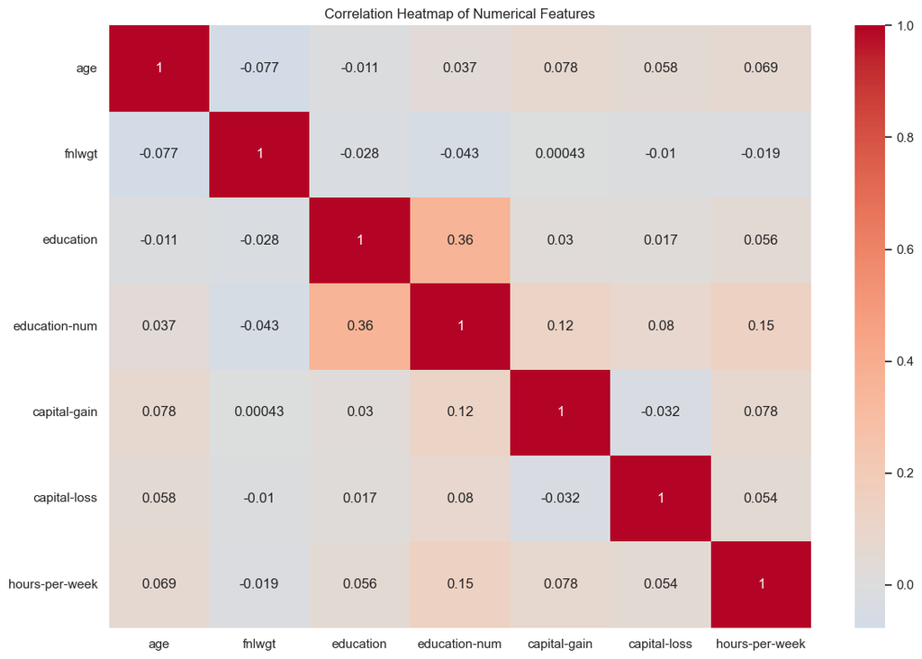

### 3.b. Feature Engineering

Based on our analysis and domain knowledge, we'll create new features that might enhance model performance:

1. Age groups (binning age into meaningful categories)
2. Income-related ratios
3. Work-life balance indicators

[output not shown]

```
Creating new features...
```

```
New features added:
Age Groups: ['36-45', '46-55', '26-35', '18-25', '56-65', '65+']
Categories (6, object): ['18-25' < '26-35' < '36-45' < '46-55' < '56-65' < '65+']

Work-Life Balance Indicators:
- standard_work_week: 15,217 instances (46.7%)
- overwork: 7,139 instances (21.9%)
- part_time: 5,583 instances (17.1%)
```

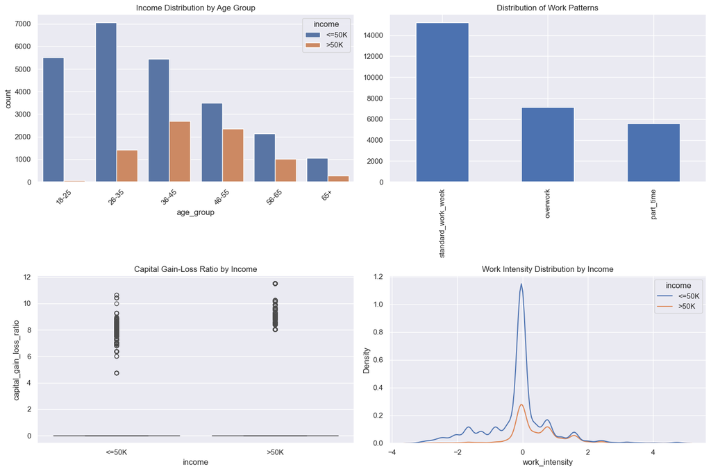

```
Feature Analysis:
1. Age Distribution:
income     <=50K   >50K
age_group
18-25      98.90   1.10
26-35      83.17  16.83
36-45      66.84  33.16
46-55      59.88  40.12
56-65      67.65  32.35
65+        79.34  20.66

2. Work Pattern Analysis:
        Standard Work Week  Overwork  Part Time
income
<=50K                78.66     58.24      93.07
>50K                 21.34     41.76       6.93
```

```
Saving dataset with new features...
Features saved successfully!
```